# Next Word Predictor

Coursera Data Science Capstone Project, Bertrand Rigaldies, October 8, 2016

- An N-grams-based probabilistic model to predict the next most likely words in an english sentence (See example of R output below);
- Using Maximum Likelihood Estimates (MLE) probabilities, and Stupid Backoff Algorithm-based prediction;
- Achieving about 55% prediction success rate;
- Deployed on Shinyapps.io.

```r
predictWithStupidBackoff(model = model, sentence = 'as far as I can', matches_count_max = 5)
```

```
                gram   logprob last_word_in_gram      sprob
1: as i can remember -1.953815          remember 0.14173228
2:     as i can tell -2.446292              tell 0.08661417
3:        as i can i -2.541602                 i 0.07874016
4:  as i can because -2.764746           because 0.06299213
5:      as i can and -3.234749               and 0.03937008
```

### The Probabilistic Model

- English Corpus from HC Corpora.
- 10% of the English Corpus used as training dataset.
- 5 N-grams tables built from the training dataset, N = 1 to 5.
- Each N-gram table is structured as follows:

| Column | Description |
| --- | --- |
| **gram** | The gram as a string of one (\( N=1 \)) or more (\( N\gt2 \)) words. |
| **count** | The number of times the gram is used in the Corpus training dataset. |
| **lowergram** | The preceding lower-order gram when \( N\gt2 \), or “lowergram” (e.g., “in the” in gram “in the world”). |
| **last_word_in_gram** | The last word in the gram (e.g., “world” in gram “in the world”). |
| **logprob** | Logarithm of the gram's **Maximum Likelihood Estimation** (MLE). |
| **logpercent** | Logarithm of the gram's **Percent Use** (PU) based on the gram's count. |

**Maximum Likelihood Estimation**: \( P_{MLE}(w_1 \ldots w_n) = P(w_n|w_1 \ldots w_{n-1}) = \frac{Count(w_1 \ldots w_n)}{Count(w_1 \ldots w_{n-1})} \)

**Percent Use**: \( P_{PU}(w_1 \ldots w_n) = \frac{Count(w_1 \ldots w_n)}{Count(n-Grams)} \)

### The Stupid Backoff Algorithm

Reference: [Speech and Language Processing, Daniel Jurafsky & James H. martin, January 9, 2015, Chapter 4: N-Grams, section 4.5.1 The Web and Stupid Backoff](https://web.stanford.edu/%7Ejurafsky/slp3/4.pdf)

The basic flow is:

1. Lookup the top 10 matches in the highest order N-gram table in the model, where lowergram = last (N-1) words in the input sentence;
2. If less than 10 matches were found, **back off** and look up for additional matches in the (N-1)-gram table;
3. At each backoff, *discount* the matches' MLE probabilities by applying a \( \lambda \) weight. (e.g., \( \lambda=0.4 \)): \( P_{MLE(weighted)}(w_{1} \ldots w_{N-1}w_{match}) = \lambda^{(4 - (N-1))} * P_{MLE}(w_{1} \ldots w_{N-1}w_{match}) \)
4. Repeat the previous step until 10 matches are found, using the unigrams table as the last lookup step;
5. Return the top 10 matches (or predictions), sorted by \( \lambda\ \)-weighted MLE descending.

### Quantitative Predictive Performance: ~55%

- Sample 10% of the non-training data in the English Corpus to create a test dataset;
- Build a bi, tri, quad, and pentagrams from the test dataset;
- For each N-gram, build a `data.table` with the following columns: a) `gram`: The gram; b) `lowergram`: The gram's immediate lower-order gram; c) `word_to_predict`: the gram's last word;
- Sample 25,000 grams from each N-gram (N=2 to 5), and `rbind` the resulting samples into a 100,000-row table (Samples of the resulting test data shown below):

```
                    gram   lowergram word_to_predict
1:        are we to make   are we to            make
2: make better decisions make better       decisions
3:          its too much     its too            much
```

- **Success Criteria**: For each `gram` in the test `data.table`, run the Stupid Backoff prediction on the `lowergram`, and if the resulting 10 predictions contain the gram's `word_to_predict`, then the test is a PASS, else the test is a FAIL (Test samples shown below):

  |  | Test Gram | Word to Predict | Top 10 Predicted Words | Test Result |
  | --- | --- | --- | --- | --- |
  | 1 | i feel like being | being | i, im, a, the, it, ive, its, my, such, this | FAIL |
  | 2 | that matters to | to | is, to, its, what, of, worse, most, and, the, in | PASS |
  | 3 | to the vast | vast | next, point, public, new, us, top, world, city, hospital, state | FAIL |

### My Shinyapps.io Application

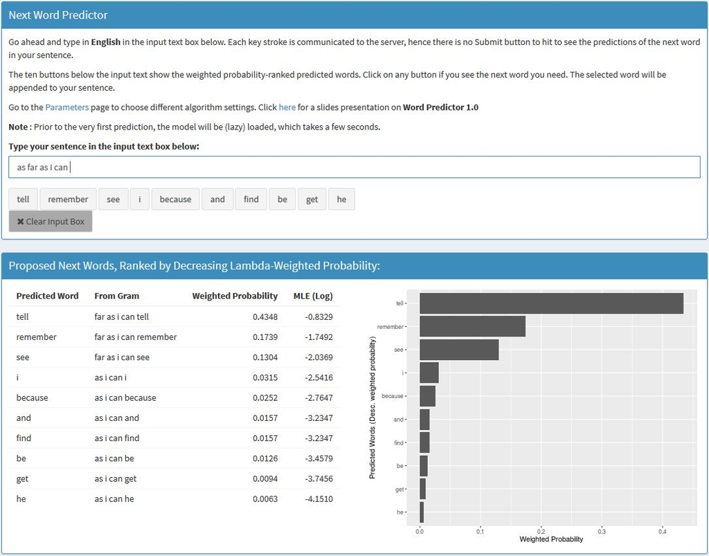